# RandomForestOptimizado

## Actividad 03: Regresión

### Sebastián Hernández Mantilla

## Predicción del precio de la vivienda en Taiwan

#### El ejercicio de predicción fue desarrollado en python con ayuda de las librerías de Sickit Learn y Keras. La medida de error usada fue el error cuadratico medio (MSE).

#### El impacto de las variables para cada modelo se obtuvo de ScikitLearn y para la visualización de esto se tomó el valor absoluto. En primer lugar se hace un breve análisis visual de los datos y luego se presenta, para cada modelo, el código usado, el resultado del error y una gráfica con el impacto de las variables.

```python
import pandas as pd
import numpy as np
import seaborn as sns
df = pd.read_excel('Real estate valuation data set.xlsx',index_col='No')
df.head()
```

| No | X1 transaction date | X2 house age | X3 distance to the nearest MRT station | X4 number of convenience stores | X5 latitude | X6 longitude | Y house price of unit area |
| --- | --- | --- | --- | --- | --- | --- | --- |
| 1 | 2012.916667 | 32.0 | 84.87882 | 10 | 24.98298 | 121.54024 | 37.9 |
| 2 | 2012.916667 | 19.5 | 306.59470 | 9 | 24.98034 | 121.53951 | 42.2 |
| 3 | 2013.583333 | 13.3 | 561.98450 | 5 | 24.98746 | 121.54391 | 47.3 |
| 4 | 2013.500000 | 13.3 | 561.98450 | 5 | 24.98746 | 121.54391 | 54.8 |
| 5 | 2012.833333 | 5.0 | 390.56840 | 5 | 24.97937 | 121.54245 | 43.1 |

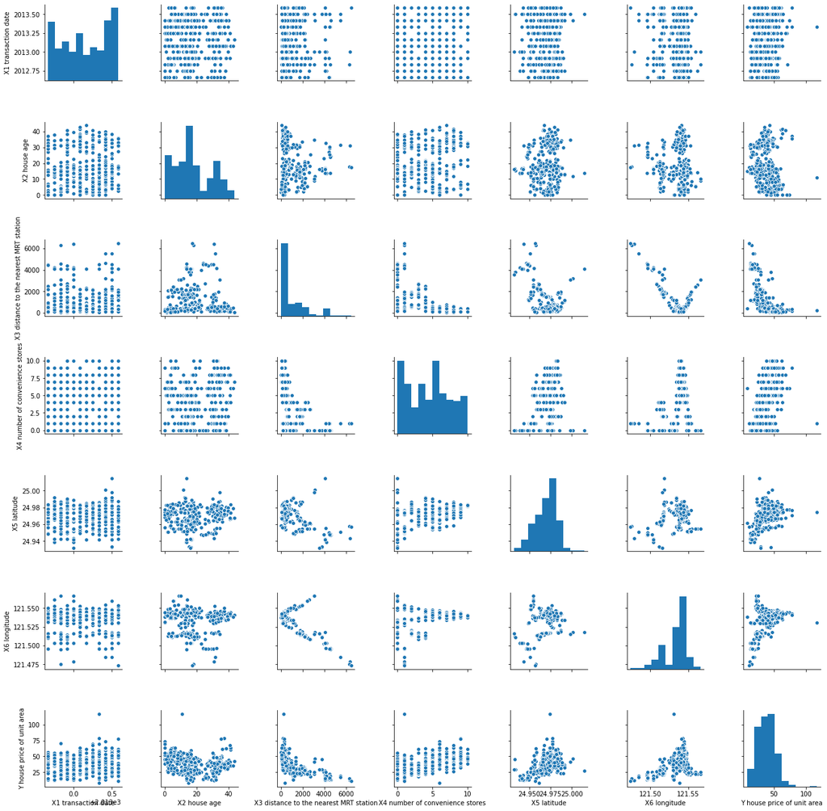

```python
sns.pairplot(df)
```

### Variable Y, (Precio/U de area):

- Se observa que a mayor número de tiendas cercanas el precio tiende a crecer ligeramente
- La distancia a la estación de transporte masivo mas cercana y el precio muestra una relación inversa donde las casas con mayor precio estan mas cerca a una estación.
- Para la longitud y latitud el precio crece a mayor sean los valores de las 2 variables

### Relación entre variables predictivas:

- Se observa que la variable X3, (distancia a la estación de transporte masivo más cercano), tiende a valores muy bajos para ciertos valores de X5 y X6, (longitud y latitud), de esto se infiere que la mayor cantidad de estaciones están centradas en una ubicación especifica.
- Hay mayor cantidad de tiendas alrededor de las casas más cercanas a una estación de transporte masivo

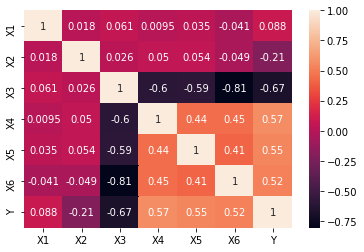

```python
import matplotlib.pyplot as plt
df_=df.rename(columns={"X1 transaction date":"X1",'X2 house age':'X2','X3 distance to the nearest MRT station':'X3',
                       'X4 number of convenience stores':'X4','X5 latitude':'X5','X6 longitude':'X6',
                       'Y house price of unit area':'Y'})
corrMatrix = df_.corr()
sns.heatmap(corrMatrix, annot=True)
plt.show()
```

### De la matriz de correlación:

- X3 tiene los valores más altos de correlación con las variables predictivas X4,X5,X6 y la variable Y a predecir.
- X1 tiene los valores más bajos con el resto de variables, por lo que no se tendrá en cuenta para el entrenamiento de los modelos

### Descripción del data set

```python
df.drop(['X1 transaction date'],axis=1,inplace=True)
df.describe()
```

|  | X2 house age | X3 distance to the nearest MRT station | X4 number of convenience stores | X5 latitude | X6 longitude | Y house price of unit area |
| --- | --- | --- | --- | --- | --- | --- |
| count | 414.000000 | 414.000000 | 414.000000 | 414.000000 | 414.000000 | 414.000000 |
| mean | 17.712560 | 1083.885689 | 4.094203 | 24.969030 | 121.533361 | 37.980193 |
| std | 11.392485 | 1262.109595 | 2.945562 | 0.012410 | 0.015347 | 13.606488 |
| min | 0.000000 | 23.382840 | 0.000000 | 24.932070 | 121.473530 | 7.600000 |
| 25% | 9.025000 | 289.324800 | 1.000000 | 24.963000 | 121.528085 | 27.700000 |
| 50% | 16.100000 | 492.231300 | 4.000000 | 24.971100 | 121.538630 | 38.450000 |
| 75% | 28.150000 | 1454.279000 | 6.000000 | 24.977455 | 121.543305 | 46.600000 |
| max | 43.800000 | 6488.021000 | 10.000000 | 25.014590 | 121.566270 | 117.500000 |

### Preparación de la data

```python
# Se inicializa la herramienta para escalar los datos
X = df.drop(['Y house price of unit area'],axis=1)

from sklearn.preprocessing import StandardScaler
scaler = StandardScaler()
```

```python
from sklearn.model_selection import train_test_split
# Se quiere usar un modelo solo con latitud y longitud , otro con el resto de variables y otro con todas las variables
X1 = X.drop(['X5 latitude','X6 longitude'],axis=1)
scaled_x = scaler.fit_transform(X1)
# Se dividen los datos en 80-20 para el set de entrenamiento y de testeo
X_train,X_test,y_train,y_test = train_test_split(scaled_x,df['Y house price of unit area'],test_size = 0.2, random_state=42)

# Para los modelos solo con ubicación
X_train2,X_test2,y_train2,y_test2 = train_test_split(df.iloc[:, 3:5],df['Y house price of unit area'],
                                                 test_size = 0.2, random_state=42)
```

```python
# Se quiere usar un modelo solo con latitud y longitud , otro con el resto de variables y otro con todas las variables
scaled_x = scaler.fit_transform(X)
# Se dividen los datos en 80-20 para el set de entrenamiento y de testeo
X_train1,X_test1,y_train1,y_test1 = train_test_split(scaled_x,df['Y house price of unit area'],test_size = 0.2, random_state=42)
```

### Regresión lineal clásica

```python
from sklearn.linear_model import LinearRegression
from sklearn.metrics import mean_squared_error

reg3 = LinearRegression().fit(X_train1,y_train1)
y_pred = reg3.predict(X_test1)

print('Error MSE: ')
print(mean_squared_error(y_test1, y_pred))
```

```
Error MSE:
54.58094520086212
```

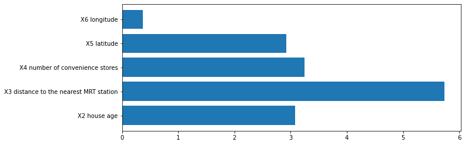

```python
import matplotlib.pyplot as plt
fig = plt.figure(figsize=(8, 3))
ax = fig.add_axes([0,0,1,1])
variables = X.columns
importancia = np.absolute(reg3.coef_)
ax.barh(variables,importancia)
plt.show()
```

```python
from sklearn.linear_model import LinearRegression
from sklearn.metrics import mean_squared_error

reg = LinearRegression().fit(X_train,y_train)
y_pred = reg.predict(X_test)

print('Error MSE: ')
print(mean_squared_error(y_test, y_pred))
reg_coef = reg.coef_
```

```
Error MSE:
58.88825128983576
```

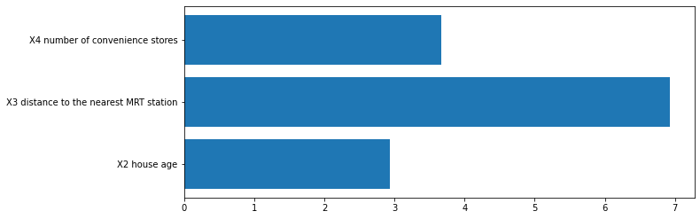

```python
import matplotlib.pyplot as plt
fig = plt.figure(figsize=(8, 3))
ax = fig.add_axes([0,0,1,1])
variables = X1.columns
importancia = np.absolute(reg.coef_)
ax.barh(variables,importancia)
plt.show()
```

```python
reg2 = LinearRegression().fit(X_train2,y_train2)
y_pred = reg2.predict(X_test2)

print('Error MSE: ')
print(mean_squared_error(y_test2, y_pred))
reg_coef = reg.coef_
```

```
Error MSE:
82.08014010115268
```

### Regresión lineal Elastic Net

```python
from sklearn.linear_model import ElasticNet
reg_elast = ElasticNet()
reg_elast.fit(X_train1,y_train1)
y_pred = reg_elast.predict(X_test1)
print('Error MSE: ')
print(mean_squared_error(y_test, y_pred))
reg_elast_coef = reg_elast.coef_
```

```
Error MSE:
61.35399330573307
```

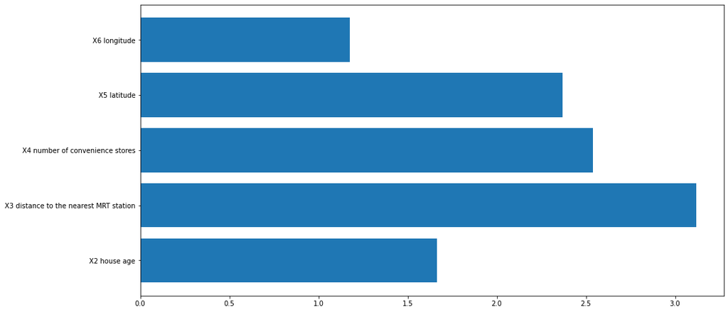

```python
fig = plt.figure(figsize=(12, 6))
ax = fig.add_axes([0,0,1,1])
variables = df.columns[0:-1]
importancia = np.absolute(reg_elast.coef_)
ax.barh(variables,importancia)
plt.show()
```

### Random Forest

```python
print(importancia)
```

[output not shown]

```python
# Debido a que los arboles no son afectados por la escala de los datos, en este caso, se usan todas las variables
X_train,X_test,y_train,y_test = train_test_split(X,df['Y house price of unit area'],test_size = 0.2, random_state=42)
```

```python
from sklearn.ensemble import RandomForestRegressor
random_forest = RandomForestRegressor()
random_forest.fit(X_train, y_train)
y_pred = random_forest.predict(X_test)
print('Error MSE: ')
print(mean_squared_error(y_test, y_pred))
```

```
Error MSE:
35.063981276509196
```

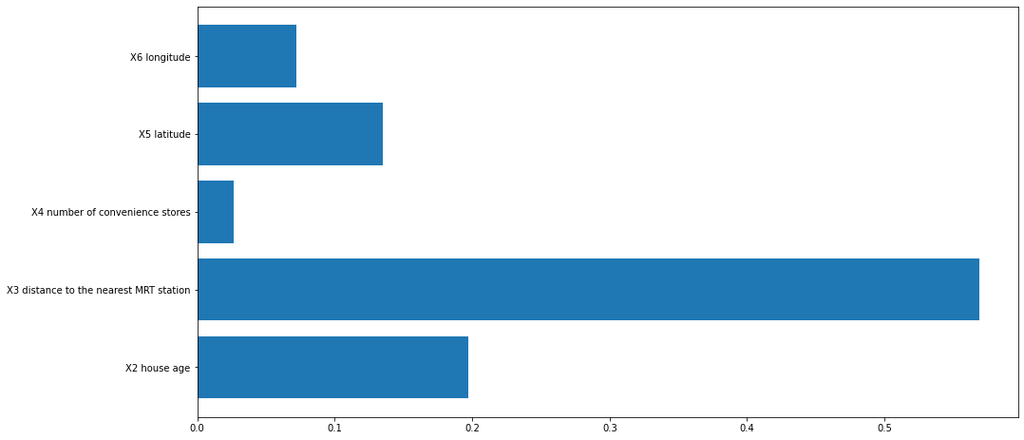

```python
fig = plt.figure(figsize=(12, 6))
ax = fig.add_axes([0,0,1,1])
variables = X.columns
importancia = np.absolute(random_forest.feature_importances_)
ax.barh(variables,importancia)
plt.show()
```

### Optimización de Random Forest

##### Se utilizó la librería RandomizedSearchCv la cual prueba la malla de hiperparametros y usa validación cruzada para cada iteración

```python
from sklearn.model_selection import RandomizedSearchCV

#CREACIÓN DE LA MALLA:

# Cantidad de arboles
n_estimators = [int(x) for x in np.linspace(start = 100, stop = 1000, num = 10)]
# Número de features a considerar para encontrar la mejor separación
max_features = ['auto', 'sqrt', 'log2']
# Profundidad máxima de los arboles
max_depth = [int(x) for x in np.linspace(10, 110, num = 11)]
max_depth.append(None)
# Cantidad mínima de registros para partir un nodo
min_samples_split = [2, 5, 10, 15, 20]
# Cantidad mínima de registros en cada hoja
min_samples_leaf = [1, 2, 4]
# Metodo de elección de registros para entrenar cada arbol
bootstrap = [True, False]


random_grid = {'n_estimators': n_estimators,
               'max_features': max_features,
               'max_depth': max_depth,
               'min_samples_split': min_samples_split,
               'min_samples_leaf': min_samples_leaf,
               'bootstrap': bootstrap}

print(random_grid)
{'bootstrap': [True, False],
 'max_depth': [10, 20, 30, 40, 50, 60, 70, 80, 90, 100, None],
 'max_features': ['auto', 'sqrt'],
 'min_samples_leaf': [1, 2, 4],
 'min_samples_split': [2, 5, 10],
 'n_estimators': [200, 400, 600, 800, 1000, 1200, 1400, 1600, 1800, 2000]}
```

[output not shown]

[output not shown]

```python
# Se crea un modelo nuevo y se evalua en la malla de hiperparametros
from sklearn.ensemble import RandomForestRegressor
random_forest = RandomForestRegressor()

# Se divide los datos en 3 grupos para hacer la validación cruzada en cada iteración
# Se ejecuta con máximo 200 iteraciones
rf_random = RandomizedSearchCV(estimator = random_forest, param_distributions = random_grid,
                               n_iter = 200, cv = 3, verbose=1, random_state=42, n_jobs = -1)

rf_random.fit(X_train, y_train)

# Mejores parametros
rf_random.best_params_
```

```
Fitting 3 folds for each of 200 candidates, totalling 600 fits
```

```
[Parallel(n_jobs=-1)]: Using backend LokyBackend with 8 concurrent workers.
[Parallel(n_jobs=-1)]: Done  34 tasks      | elapsed:   21.1s
[Parallel(n_jobs=-1)]: Done 184 tasks      | elapsed:   40.9s
[Parallel(n_jobs=-1)]: Done 434 tasks      | elapsed:  1.3min
[Parallel(n_jobs=-1)]: Done 600 out of 600 | elapsed:  1.7min finished
```

```
{'n_estimators': 900,
 'min_samples_split': 2,
 'min_samples_leaf': 2,
 'max_features': 'auto',
 'max_depth': 100,
 'bootstrap': True}
```

```python
# Se reevalua con los nuevos parámetros
from sklearn.ensemble import RandomForestRegressor

random_forest = RandomForestRegressor(n_estimators=900, min_samples_split=2, min_samples_leaf=2,max_features='auto',
                                      max_depth=100,bootstrap=True)

random_forest.fit(X_train, y_train)
y_pred = random_forest.predict(X_test)
print('Error MSE: ')
print(mean_squared_error(y_test, y_pred))
```

```
Error MSE:
31.40715463060185
```

#### Conclusión

- Se tuvo una disminución del error con respecto al modelo usado en un principio
- La busqueda de hiperparametros se hizo con n_iter, (número máximo de iteraciones), de 50, 100 y 200 cada vez obteniendo menos error, esto indica que el error puede ser disminuido aún más con mayor cantidad de iteraciones máximas
- La malla construida puede no estar dentro del intervalo de parametros donde se encuentra la combinación de hiperparametros óptimos, esto se puede mejorar con una malla más amplia o con otra malla con diferentes rangos

### XG Boost

```python
from xgboost import XGBRegressor
#xg = XGBRegressor(n_estimators=100, max_depth=10, eta=0.1, subsample=0.7, colsample_bytree=0.8)
xg = XGBRegressor()

xg.fit(X_train, y_train)
y_pred = xg.predict(X_test)

print('Error MSE: ')
print(mean_squared_error(y_test, y_pred))
xg_coef = xg.feature_importances_
```

```
Error MSE:
39.8139344587423
```

```python
xg_coef
```

```
array([0.0463699 , 0.664023  , 0.06194649, 0.12445176, 0.1032089 ],
      dtype=float32)
```

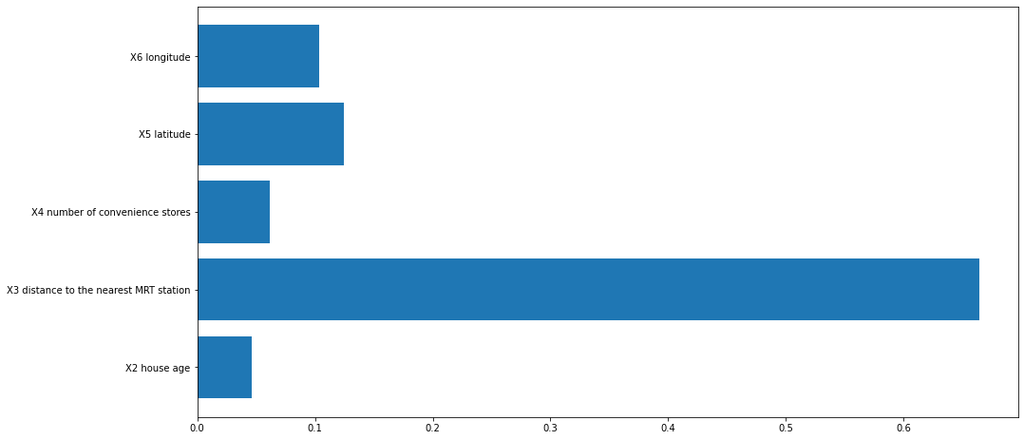

```python
fig = plt.figure(figsize=(12, 6))
ax = fig.add_axes([0,0,1,1])
variables = df.columns[0:-1]
importancia = np.absolute(xg.feature_importances_)
ax.barh(variables,importancia)
plt.show()
```

### Support Vectors Machines

#### Para SVM y la red neuronal se estandarizó la data usando la herramienta StandardScaler de sklearn, la ecuación usada en esta operación es:

y = (x – mean) / standard_deviation

```python
from sklearn.preprocessing import StandardScaler
scaler = StandardScaler()
scaled_y = df['Y house price of unit area']
scaled_x = scaler.fit_transform(df.drop(columns=['Y house price of unit area'],axis=1))

X_train,X_test,y_train,y_test = train_test_split(scaled_x,scaled_y,test_size = 0.2, random_state=42)
```

```python
from sklearn.svm import SVR
svm = SVR(kernel='linear')
svm.fit(X_train1,y_train1)
y_pred = svm.predict(X_test1)
print('Error MSE: ')
print(mean_squared_error(y_test1, y_pred))
#svm.coef_
```

```
Error MSE:
60.725841689226584
```

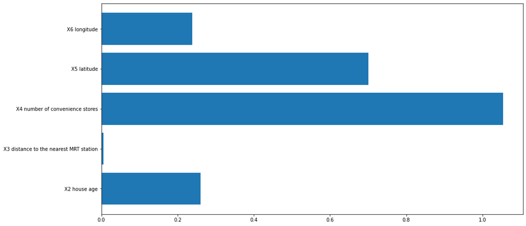

```python
fig = plt.figure(figsize=(12, 6))
ax = fig.add_axes([0,0,1,1])
variables = X.columns
importancia = np.absolute(svm.coef_[0])
ax.barh(variables,importancia)
plt.show()
```

### Red Neuronal

```python
from keras.models import Sequential
from keras.layers import Dense

model = Sequential()
model.add(Dense(12, input_dim=5, kernel_initializer='normal', activation='relu'))
model.add(Dense(8, activation='relu'))
model.add(Dense(1, activation='linear'))
#model.summary()
model.compile(loss='mse', optimizer='adam', metrics=['mse','mae'])
hist = model.fit(X_train1, y_train1, epochs=75, batch_size=50,  verbose=1, validation_split=0.2)
y_pred= model.predict(X_test1)
```

#### Para encontrar la importancia de las variables dada por la red neuronal se usó un array de zeros con un 1 en la posición donde se quería obtener el coeficiente y se predijo este array con el modelo anteriormente entrenado.

```python
RN_coef=np.zeros((1,5))
for i in range(0,5):
  inputs = np.zeros((1,5))
  inputs[0][i] = 1
  tmp_coef = model.predict(inputs)
  RN_coef[0][i] = tmp_coef
  #print(inputs)
RN_coef
```

```
array([[0.29726771, 0.42819554, 0.77327377, 0.69600338, 0.74332511]])
```

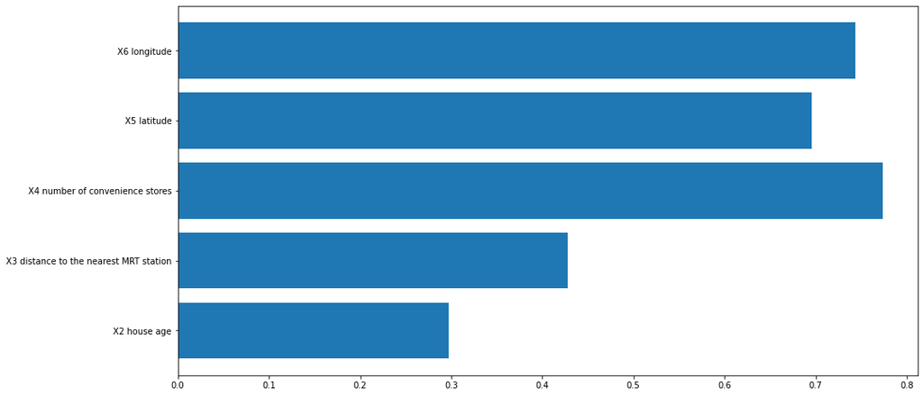

```python
fig = plt.figure(figsize=(12, 6))
ax = fig.add_axes([0,0,1,1])
variables = df.columns[0:-1]
importancia = np.absolute(RN_coef[0])
ax.barh(variables,importancia)
plt.show()
```

```python
print('Error MSE: ')
print(mean_squared_error(y_test, y_pred))
```

```
Error MSE:
51.70303779164877
```

### **¿Qué variables tienen el mayor impacto en el precio de la vivienda? ¿Cómo aporta cada modelo al conocimiento de este impacto?**

- Para la regresión lineal clásica y elastic y los modelos de ensamble se obtuvo que la variable más importantes fue la distancia la estación de transporte masivo más cercana
- En máquinas de soporte vectorial la variable mas importante fue X4 (cantidad de tiendas cercanas), y al contrario de los primeros modelos X3 no tuvo mucho peso
- La red neuronal le dio mucha importancia a la ubicación (latitud y longitud) y la cantidad de tiendas cercanas

### **¿Cuál es el mejor modelo entre los usados para resolver este problema? ¿Qué criterios se pueden utilizar para responder a esta pregunta?**

#### Otras medidas comunmente usadas para medir el nivel de error en modelos de regresión son RMSE y MAE, (muy parecidos al error MSE usado en la actividad), y el coeficiente de determinación (R²)

#### En la regresión lineal clásica para entender mejor el impacto de las variables de ubicación en los modelos, se usaron 3 data sets, uno con todas las variables estandarizadas, otro sin las variables de latitud y longitud y otro solo con latitud y longitud. De estos modelos el mejor fue el que se entrenó con todas las variables estandarizadas

#### Estandarización :

y = (x – mean) / standard_deviation